# Multifactor Analysis MFA

Antonio Miñarro (aminarro@ub.edu)

30 setembre, 2025

# 1 Introduction to Multifactor Analysis (MFA)

## 1.1 What is MFA?

**Multifactor Analysis (MFA)** is a multivariate analysis technique that allows analyzing data sets where variables are organized into groups. This technique is useful for identifying common structures between groups and the specificities of each group.

It is especially useful when groups of variables have different units of measurement or importance.

This method is an extension of *PCA (Principal Component Analysis)*, but considers information structured into blocks of variables.

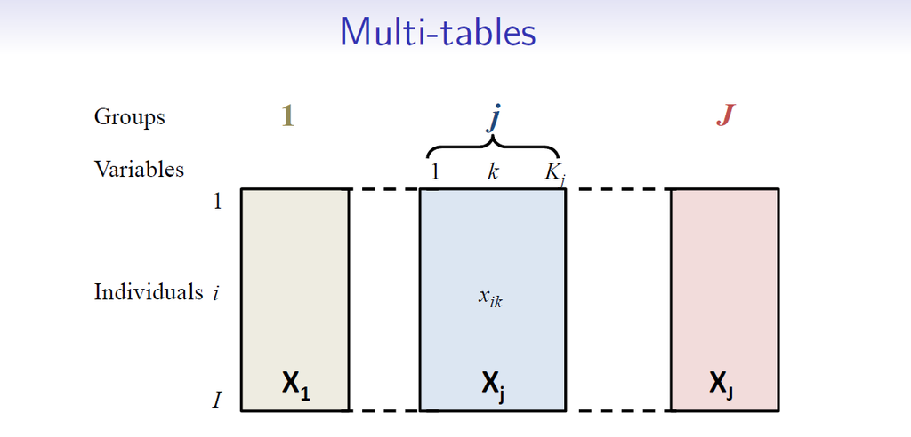

mfa1

## 1.2 Why use MFA?

- **Integration of multiple data sources**: Allows combining data from different sources or blocks of variables.
- **Group comparison**: Facilitates the comparison of results from several principal component analyses (PCA) or multiple correspondence analyses (MCA) in a single frame of reference.
- **Identification of common structures**: Helps identify common structures and specificities between groups of variables.

## 1.3 Objectives

- Study the similarity between individuals with respect to the entire set of variables AND the relationships between variables.

### 1.3.1 Take into account group structure

- Study the general similarities and differences between groups (and the specific characteristics of each group).
- Study the similarities and differences between groups from an individual point of view.
- Compare the characteristics of individuals based on separate analyses.

**⇒ Balance the influence of all groups in the analysis.**

## 1.4 How an MFA works

**MFA** starts from the same principle as **PCA**, but incorporates **groups of variables** $G_1, G_2, \dots, G_J$, each with $p_j$ variables and a total of I individuals in the sample.

- In a PCA, normalization balances the influence of each variable
- In an MFA, we balance in terms of groups

A MFA is a PCA weighted by the variability of the groups

### 1.4.1 **Weighting of each group**

The total inertia of the cloud of individuals (identical to that of the cloud of variables) can be expressed, highlighting the role of each group of variables (we assume that the data are centered) as
$$\text{Total inertia} = \sum_i d^2(O, i) = \sum_i
\sum_k z_{ik}^2 = \sum_j \sum_{k \in K_j} \sum_i z_{ik}^2 = \sum_j
\sum_{k \in K_j} Var[k]$$

$$\text{Total intertia} = \sum_{i=1}^{p_J} \lambda_i$$

To ensure that each group has the same contribution, we divide its data by the **first eigenvalue of its individual PCA**:

- We calculate the first eigenvalue $\lambda_1^j$ of the group $j$ of variables $(j=1,...,J)$
- We perform a global PCA on the transformed data

$$\left(
\frac{Z_1}{\sqrt{\lambda_1^1}};\frac{Z_2}{\sqrt{\lambda_1^2}};...;\frac{Z_J}{\sqrt{\lambda_1^J}}
\right)$$
The $Z_j$ would be the normalized data of a group of variables.

$$Z_j^* = \frac{Z_j}{\sqrt{\lambda_1^j}}$$

where $\lambda_1^j$ is the first eigenvalue of the **PCA of the group $j$**.

### 1.4.2 **Global PCA**

Once the groups have been rescaled, the information is concatenated into a new normalized matrix:

$$Z^* = [Z_1^* | Z_2^* | \dots | Z_J^*]$$

and a **global PCA** is performed on $Z^*$, obtaining **balanced principal components between groups**.

- The weights are the same for all variables in the same group: the group structure is preserved.
- For each group, the variance of the first dimension (first eigenvalue) is equal to 1.

## 1.5 **Key differences between PCA and MFA**

| Method | Input matrix | Initial weighting | Component calculation |
| --- | --- | --- | --- |
| **PCA** | Data matrix $X$ | All variables equal | $S v = \lambda v$ |
| **MFA** | Concatenated matrix $Z^*$ | Each group weighted by $\lambda_1^j$ | Global PCA over $Z^*$ |

In an **MFA** we have data structured into groups and we want to make sure that no group dominates the analysis.

# 2 The FactoMineR package

The FactoMineR package in R is a powerful tool for performing MFA. It provides functions for exploratory analysis of multivariate data and data mining.

## 2.1 Example dataset

We will work with some metabolic syndrome data obtained from **Kaggle** https://www.kaggle.com/datasets/antimoni/metabolic-syndrome

This dataset contains information about people with metabolic syndrome, a complex medical condition associated with a cluster of risk factors for cardiovascular disease and type 2 diabetes. The data include demographic, clinical, and laboratory measures, as well as the presence or absence of metabolic syndrome.

To facilitate interpretation, we randomly select 50 individuals from the original set.

```r
set.seed(1234)
dades<-read.csv("Metabolic Syndrome.csv")
dades$Marital[dades$Marital==""]<-NA
dades<-dades[complete.cases(dades),]
dades<-dades[sample(1:nrow(dades),50),]
dades$MetabolicSyndrome<-as.factor(dades$MetabolicSyndrome)
for (i in c(3,4,6)) dades[,i]<-as.factor(dades[,i])
DT::datatable(dades)
```

|  | seqn | Age | Sex | Marital | Income | Race | WaistCirc | BMI | Albuminuria | UrAlbCr | UricAcid | BloodGlucose | HDL | Triglycerides | MetabolicSyndrome |
| --- | --- | --- | --- | --- | --- | --- | --- | --- | --- | --- | --- | --- | --- | --- | --- |
| 1564 | 68570 | 49 | Male | Divorced | 1000 | White | 87.2 | 23.2 | 0 | 8.75 | 5 | 124 | 62 | 75 | 0 |
| 2230 | 71185 | 29 | Male | Married | 3500 | MexAmerican | 90.9 | 22.8 | 0 | 3.74 | 5.2 | 109 | 62 | 119 | 0 |
| 1235 | 67209 | 80 | Female | Widowed | 2000 | White | 97.8 | 25.5 | 1 | 46.1 | 3.5 | 119 | 88 | 159 | 1 |
| 2314 | 71536 | 44 | Female | Divorced | 1000 | White | 92.4 | 24.2 | 0 | 3.44 | 4.4 | 86 | 104 | 133 | 0 |
| 1361 | 67708 | 49 | Male | Married | 2500 | White | 114.6 | 31.8 | 0 | 5.48 | 7.7 | 111 | 33 | 268 | 1 |
| 1218 | 67134 | 29 | Male | Single | 5400 | Hispanic | 87.5 | 24 | 0 | 5.08 | 6 | 85 | 57 | 138 | 0 |
| 770 | 65297 | 72 | Male | Married | 1600 | Asian | 98.1 | 28.2 | 0 | 18.47 | 6.5 | 125 | 62 | 113 | 0 |
| 1105 | 66635 | 78 | Male | Married | 5400 | Asian | 99 | 26.9 | 0 | 12.29 | 7.4 | 142 | 35 | 222 | 1 |
| 796 | 65395 | 77 | Male | Single | 800 | Other | 115.9 | 32.8 | 0 | 11.43 | 7.6 | 134 | 45 | 133 | 1 |
| 1140 | 66793 | 50 | Male | Single | 3500 | Black | 107.1 | 30.8 | 0 | 10.3 | 9.8 | 97 | 40 | 213 | 1 |

[output cut: 40 more lines]

### 2.1.1 Running the Analysis

The basic function call is

```r
MFA (base, group, type = rep("s",length(group)), ind.sup = NULL,
    name.group = NULL, num.group.sup = NULL, graph = TRUE)
```

- base : a data frame with n rows (individuals) and p columns (variables)
- group: a vector with the number of variables in each group.
- type: the type of variables in each group. By default, all variables are quantitative and scaled to unit variance. Allowed values include:
  - “c” or “s” for quantitative variables. If “s”, the variables are scaled to unit variance.
  - “n” for categorical variables.
  - “f” for frequencies (from a contingency tables).
- ind.sup: a vector indicating the indexes of the supplementary individuals.
- name.group: a vector containing the name of the groups (by default, NULL and the group are named group.1, group.2 and so on).

*num.group.sup: the indexes of the illustrative groups (by default, NULL and no group are illustrative).

*graph : a logical value. If TRUE a graph is displayed.

```r
library(FactoMineR)
library(factoextra)

dades2mfa<-dades[,c(2,5,7,8,10:15)]
group<-c(2,2,5,1)
type<-c('s','s','s','n')
name.group<-c('Socio','clini','fisio','synd')
dades.mfa<-MFA(dades2mfa,group=group,type=type,name.group = name.group,graph = FALSE,num.group.sup = 4)
```

### 2.1.2 Summary of results

```r
summary(dades.mfa)
```

```
##
## Call:
## MFA(base = dades2mfa, group = group, type = type, name.group = name.group,
##      num.group.sup = 4, graph = FALSE)
##
##
## Eigenvalues
##                        Dim.1   Dim.2   Dim.3   Dim.4   Dim.5   Dim.6   Dim.7
## Variance               1.444   1.091   0.870   0.656   0.581   0.363   0.211
## % of var.             27.025  20.421  16.277  12.266  10.865   6.801   3.940
## Cumulative % of var.  27.025  47.447  63.724  75.990  86.855  93.656  97.596
##                        Dim.8   Dim.9
## Variance               0.097   0.031
## % of var.              1.818   0.587
## Cumulative % of var.  99.413 100.000
##
## Groups
##                        Dim.1    ctr   cos2    Dim.2    ctr   cos2    Dim.3
## Socio               |  0.404 27.962  0.093 |  0.462 42.367  0.121 |  0.825
## clini               |  0.386 26.714  0.149 |  0.394 36.065  0.155 |  0.032
## fisio               |  0.655 45.324  0.256 |  0.235 21.567  0.033 |  0.012
##                        ctr   cos2
## Socio               94.858  0.386 |
## clini                3.716  0.001 |
## fisio                1.426  0.000 |
##
## Supplementary group
##                       Dim.1  cos2   Dim.2  cos2   Dim.3  cos2
## synd                | 0.402 0.162 | 0.001 0.000 | 0.115 0.013 |
##
## Individuals (the 10 first)
##                        Dim.1    ctr   cos2    Dim.2    ctr   cos2    Dim.3
## 1564                | -0.479  0.318  0.100 |  0.584  0.626  0.149 | -1.240
## 2230                | -1.126  1.757  0.376 | -0.463  0.393  0.064 | -0.993
## 1235                |  0.330  0.151  0.019 |  1.921  6.766  0.646 | -0.088
## 2314                | -1.100  1.675  0.188 |  0.614  0.691  0.059 | -1.437
## 1361                |  1.394  2.689  0.395 | -1.087  2.165  0.240 | -0.286
## 1218                | -1.310  2.377  0.449 | -0.787  1.136  0.162 | -0.398
## 770                 |  0.674  0.630  0.223 |  0.898  1.477  0.395 | -0.249
## 1105                |  1.200  1.995  0.283 |  0.616  0.695  0.075 |  1.132
```

[output cut: 28 more lines]

```
## WaistCirc            1.542  0.026 |
## BMI                  2.174  0.036 |
## UrAlbCr              0.343  0.006 |
## UricAcid             0.619  0.011 |
## BloodGlucose         0.104  0.002 |
## HDL                  0.240  0.004 |
## Triglycerides        0.119  0.002 |
##
## Supplementary categories
##                        Dim.1   cos2 v.test    Dim.2   cos2 v.test    Dim.3
## MetabolicSyndrome_0 | -0.571  0.840 -4.438 |  0.029  0.002  0.256 | -0.237
## MetabolicSyndrome_1 |  1.016  0.840  4.438 | -0.051  0.002 -0.256 |  0.421
##                       cos2 v.test
## MetabolicSyndrome_0  0.145 -2.372 |
## MetabolicSyndrome_1  0.145  2.372 |
```

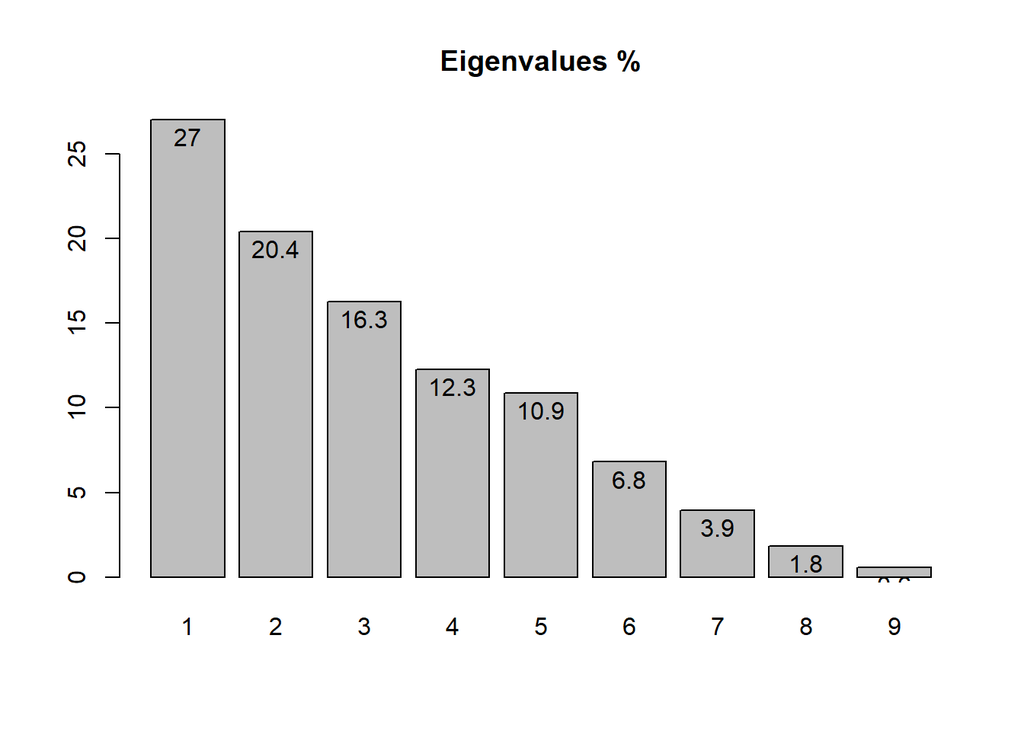

```r
aux1<-barplot(dades.mfa$eig[,2],main="Eigenvalues %",names.arg=1:nrow(dades.mfa$eig))
text(aux1,dades.mfa$eig[,2]-1,round(dades.mfa$eig[,2],1))
```

### Explained variance

```r
eig.val <- get_eigenvalue(dades.mfa)
head(eig.val)
```

```
##       eigenvalue variance.percent cumulative.variance.percent
## Dim.1  1.4443856        27.025403                    27.02540
## Dim.2  1.0914261        20.421299                    47.44670
## Dim.3  0.8699317        16.276993                    63.72370
## Dim.4  0.6555729        12.266200                    75.98990
## Dim.5  0.5806902        10.865095                    86.85499
## Dim.6  0.3634909         6.801154                    93.65614
```

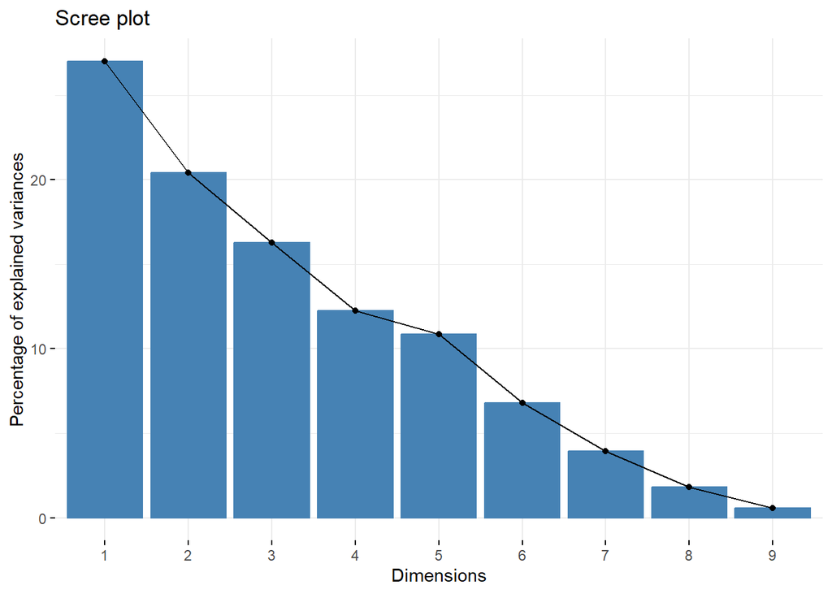

```r
fviz_eig(dades.mfa)
```

### 2.1.3 Groups of variables

The functions **get_mfa** or **get_mfa_var** allow you to extract information from individuals, qualitative or quantitative variables, groups or partial axes of the analysis.

```r
get_mfa(
  res.mfa,
  element = c("ind", "quanti.var", "quali.var", "group", "partial.axes")
)

get_mfa_var(res.mfa, element = c("quanti.var", "quali.var", "group"))
```

```r
group <- get_mfa_var(dades.mfa, "group")
group
```

```
## Multiple Factor Analysis results for variable groups
##  ===================================================
##   Name           Description
## 1 "$coord"       "Coordinates"
## 2 "$cos2"        "Cos2, quality of representation"
## 3 "$contrib"     "Contributions"
## 4 "$correlation" "Correlation between groups and principal dimensions"
```

```r
# Coordinates of groups
head(group$coord)
```

```
##           Dim.1     Dim.2      Dim.3     Dim.4      Dim.5
## Socio 0.4038794 0.4624092 0.82519818 0.1019860 0.05928020
## clini 0.3858480 0.3936282 0.03232584 0.1501856 0.02503254
## fisio 0.6546582 0.2353887 0.01240767 0.4034013 0.49637749
```

```r
# Cos2: quality of representation on the factore map
head(group$cos2)
```

```
##           Dim.1      Dim.2        Dim.3       Dim.4        Dim.5
## Socio 0.0925695 0.12134379 3.864391e-01 0.005902626 0.0019942694
## clini 0.1485828 0.15463520 1.042883e-03 0.022510901 0.0006253826
## fisio 0.2562208 0.03312502 9.203771e-05 0.097288096 0.1473021916
```

```r
# Contributions to the  dimensions
head(group$contrib)
```

```
##          Dim.1    Dim.2     Dim.3    Dim.4     Dim.5
## Socio 27.96202 42.36744 94.857813 15.55677 10.208575
## clini 26.71364 36.06549  3.715906 22.90907  4.310825
## fisio 45.32434 21.56707  1.426281 61.53416 85.480600
```

```r
# Correlations with dimensions
head(group$correlation)
```

```
##           Dim.1     Dim.2     Dim.3     Dim.4     Dim.5
## Socio 0.6355178 0.6912609 0.9646985 0.3202674 0.2458136
## clini 0.6228869 0.6284360 0.1804244 0.3876872 0.1622636
## fisio 0.8130517 0.6420848 0.1279601 0.6686358 0.8788852
```

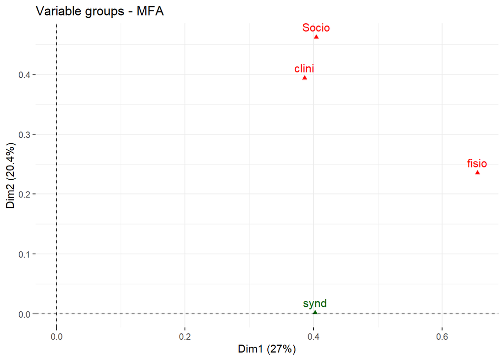

```r
# Representació gràfica
fviz_mfa_var(dades.mfa, "group")
```

- red color = active groups of variables
- green color = supplementary groups of variables

If two groups of variables have approximately the same coordinates in a dimension, it means that their contribution is similar in that dimension.

We can extract the specific contribution of each group of variables with the function

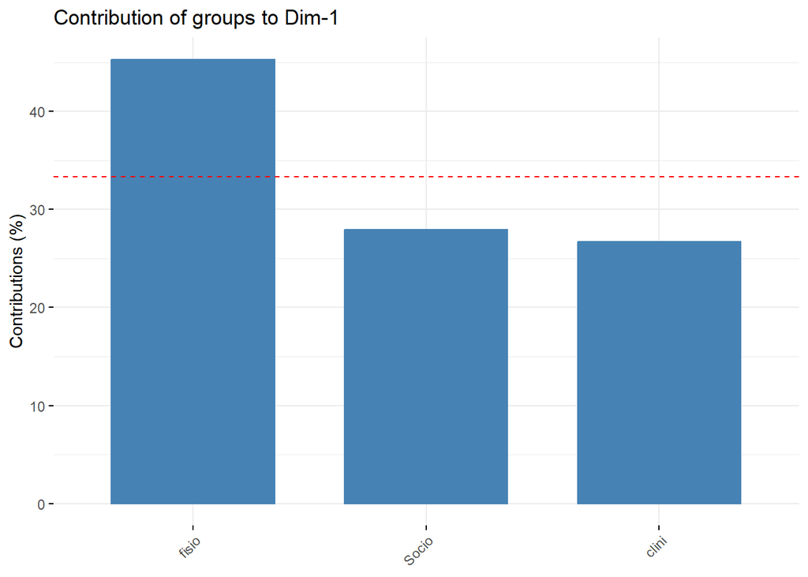

```r
# Contribution to the first dimension
fviz_contrib(dades.mfa, "group", axes = 1)
```

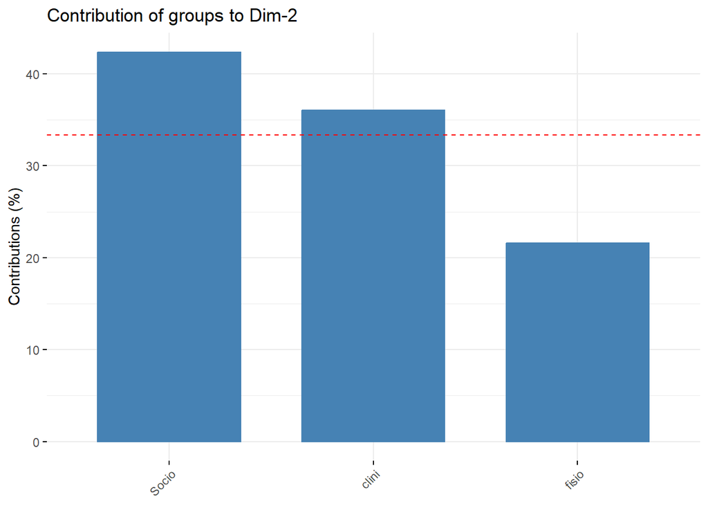

```r
# Contribution to the second dimension
fviz_contrib(dades.mfa, "group", axes = 2)
```

### 2.1.4 Quantitative variables information

```r
quanti.var <- get_mfa_var(dades.mfa, "quanti.var")
quanti.var
```

```
## Multiple Factor Analysis results for quantitative variables
##  ===================================================
##   Name       Description
## 1 "$coord"   "Coordinates"
## 2 "$cos2"    "Cos2, quality of representation"
## 3 "$contrib" "Contributions"
```

```r
head(quanti.var$coord)
```

```
##                Dim.1      Dim.2      Dim.3       Dim.4       Dim.5
## Age        0.4681621  0.6796302 0.40891821  0.27750506 -0.23279986
## Income    -0.4605324 -0.1785144 0.84494947 -0.17858451  0.09541558
## WaistCirc  0.6521762 -0.5767075 0.16023532  0.36825356  0.11560732
## BMI        0.5598186 -0.6488719 0.19030114  0.38978111  0.18590680
## UrAlbCr    0.3279082  0.2832143 0.07842777  0.20263803  0.54688891
## UricAcid   0.3371054 -0.2208546 0.10536600 -0.08881515 -0.74588162
```

```r
head(quanti.var$contrib)
```

```
##               Dim.1     Dim.2      Dim.3      Dim.4     Dim.5
## Age       14.210716 39.633056 18.0009049 11.0008785  8.740323
## Income    13.751304  2.734380 76.8569082  4.5558891  1.468252
## WaistCirc 15.380729 15.916478  1.5415638 10.8044596  1.202144
## BMI       11.332914 20.149012  2.1743417 12.1046078  3.108681
## UrAlbCr    3.613338  3.567162  0.3431955  3.0402403 25.000042
## UricAcid   3.818874  2.169231  0.6194452  0.5840366 46.503143
```

```r
head(quanti.var$cos2)
```

```
##               Dim.1      Dim.2       Dim.3      Dim.4       Dim.5
## Age       0.2191758 0.46189718 0.167214105 0.07700906 0.054195773
## Income    0.2120901 0.03186740 0.713939612 0.03189243 0.009104134
## WaistCirc 0.4253338 0.33259151 0.025675358 0.13561068 0.013365053
## BMI       0.3133968 0.42103473 0.036214524 0.15192931 0.034561339
## UrAlbCr   0.1075238 0.08021031 0.006150916 0.04106217 0.299087482
## UricAcid  0.1136401 0.04877677 0.011101995 0.00788813 0.556339398
```

```r
head(quanti.var$cor)
```

```
##                Dim.1      Dim.2      Dim.3       Dim.4       Dim.5
## Age        0.4681621  0.6796302 0.40891821  0.27750506 -0.23279986
## Income    -0.4605324 -0.1785144 0.84494947 -0.17858451  0.09541558
## WaistCirc  0.6521762 -0.5767075 0.16023532  0.36825356  0.11560732
## BMI        0.5598186 -0.6488719 0.19030114  0.38978111  0.18590680
## UrAlbCr    0.3279082  0.2832143 0.07842777  0.20263803  0.54688891
## UricAcid   0.3371054 -0.2208546 0.10536600 -0.08881515 -0.74588162
```

**Correlation between quantitative variables and dimensions**. The R code below plots quantitative variables colored by groups. The argument palette is used to change group colors. Supplementary quantitative variables are in dashed arrow and violet color. We use repel = TRUE, to avoid text overlapping.

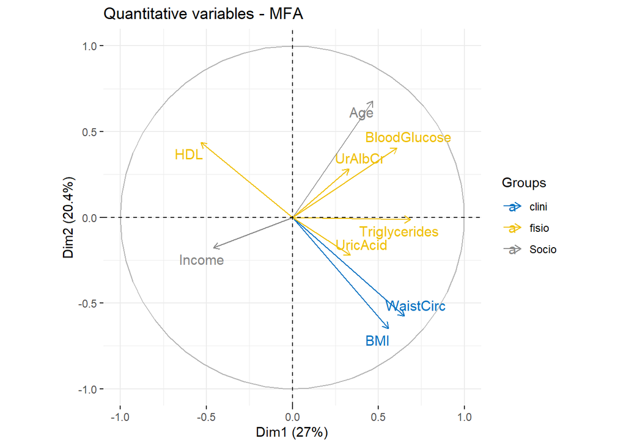

```r
fviz_mfa_var(dades.mfa, "quanti.var", palette = "jco",
             col.var.sup = "violet", repel = TRUE)
```

To make the plot more readable, we can use geom = c(“point”, “text”) instead of geom = c(“arrow”, “text”). We’ll change also the legend position from “right” to “bottom”, using the argument legend = “bottom”:

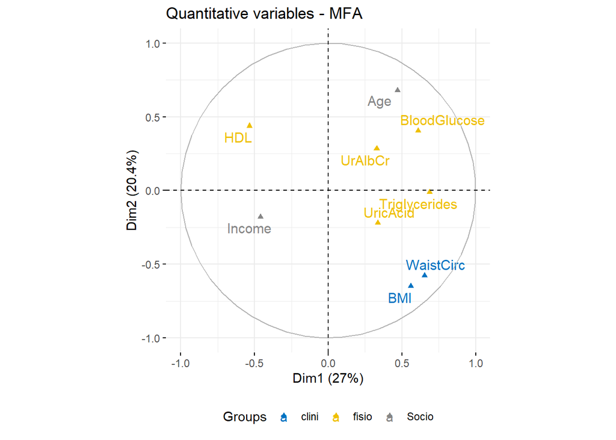

```r
fviz_mfa_var(dades.mfa, "quanti.var", palette = "jco",
             col.var.sup = "violet", repel = TRUE,
             geom = c("point", "text"), legend = "bottom")
```

Briefly, the graph of variables (correlation circle) shows the relationship between variables, the quality of the representation of variables, as well as, the correlation between variables and the dimensions:

- Positive correlated variables are grouped together, whereas negative ones are positioned on opposite sides of the plot origin (opposed quadrants).
- The distance between variable points and the origin measures the quality of the variable on the factor map. Variable points that are away from the origin are well represented on the factor map.
- For a given dimension, the most correlated variables to the dimension are close to the dimension.

The contribution of quantitative variables (in %) to the definition of the dimensions can be visualized using the function **fviz_contrib()** [factoextra package]. Variables are colored by groups. The R code below shows the top 10 variable categories contributing to the dimensions:

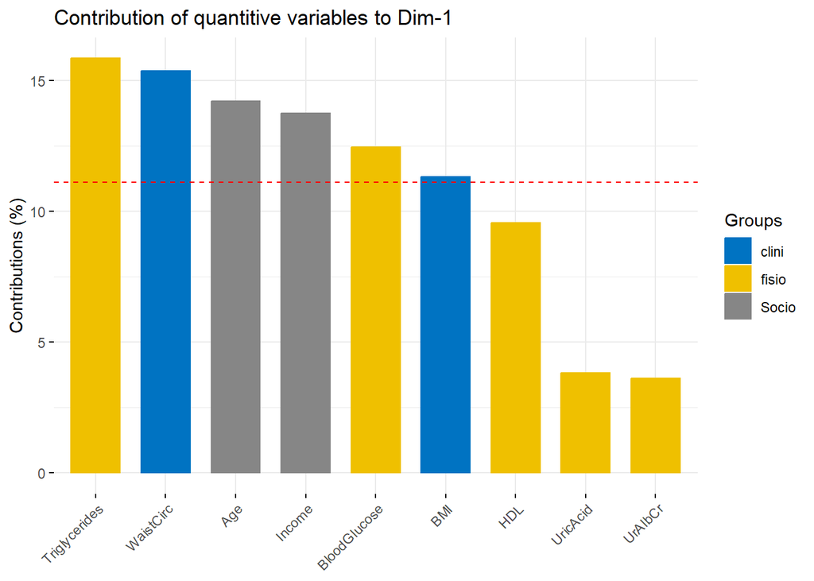

```r
# Contributions to dimension 1
fviz_contrib(dades.mfa, choice = "quanti.var", axes = 1, top = 10,
             palette = "jco")
```

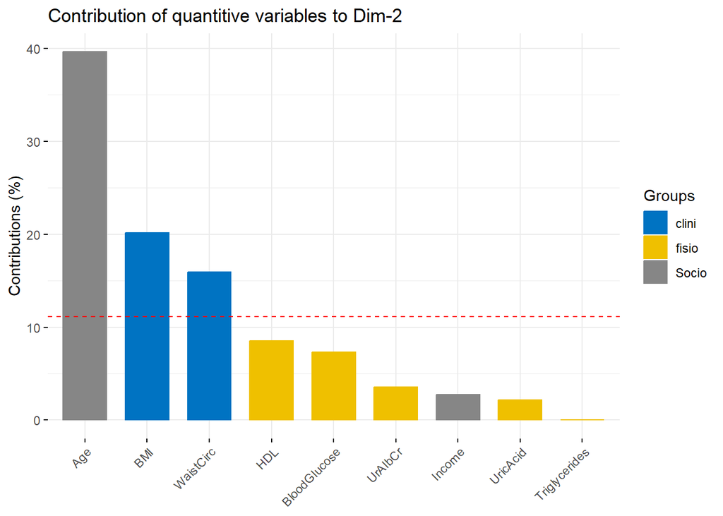

```r
# Contributions to dimension 2
fviz_contrib(dades.mfa, choice = "quanti.var", axes = 2, top = 10,
             palette = "jco")
```

The red dashed line on the graph above indicates the expected average value, If the contributions were uniform.

The most contributing quantitative variables can be highlighted on the scatter plot using the argument col.var = “contrib”. This produces a gradient colors, which can be customized using the argument gradient.cols.

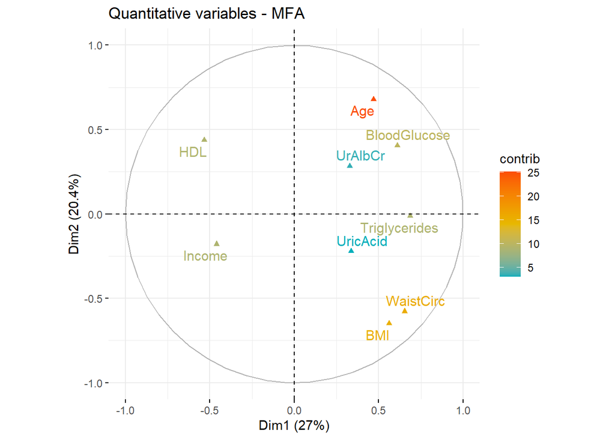

```r
fviz_mfa_var(dades.mfa, "quanti.var", col.var = "contrib",
             gradient.cols = c("#00AFBB", "#E7B800", "#FC4E07"),
             col.var.sup = "violet", repel = TRUE,
             geom = c("point", "text"))
```

Similarly, we can highlight quantitative variables using their cos2 values that represent the quality of representation in the factor map.

The quality of this representation is measured by the squared value of the cosine ($cos^2$) of the angle of the triangle formed by the origin point, the observation and the projection onto the component. For a given variable, the sum of the $cos^2$ over all dimensions will be equal to 1, and if in addition the variable is perfectly representable by only the first two dimensions, the sum of cos2 over these two will be equal to 1. Variables positioned near the origin may be an indication that more than two dimensions would be needed for their representation.

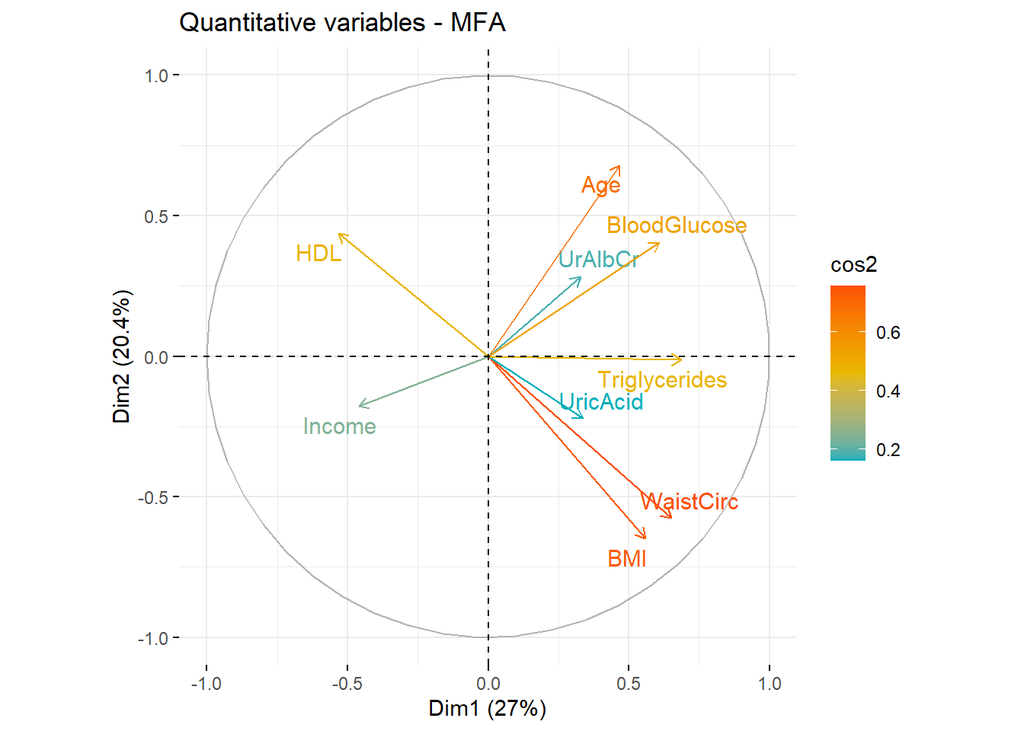

```r
# Color by cos2 values: quality on the factor map
fviz_mfa_var(dades.mfa, col.var = "cos2",
             gradient.cols = c("#00AFBB", "#E7B800", "#FC4E07"),
             col.var.sup = "violet", repel = TRUE)
```

To create a bar plot of variables cos2, type this:

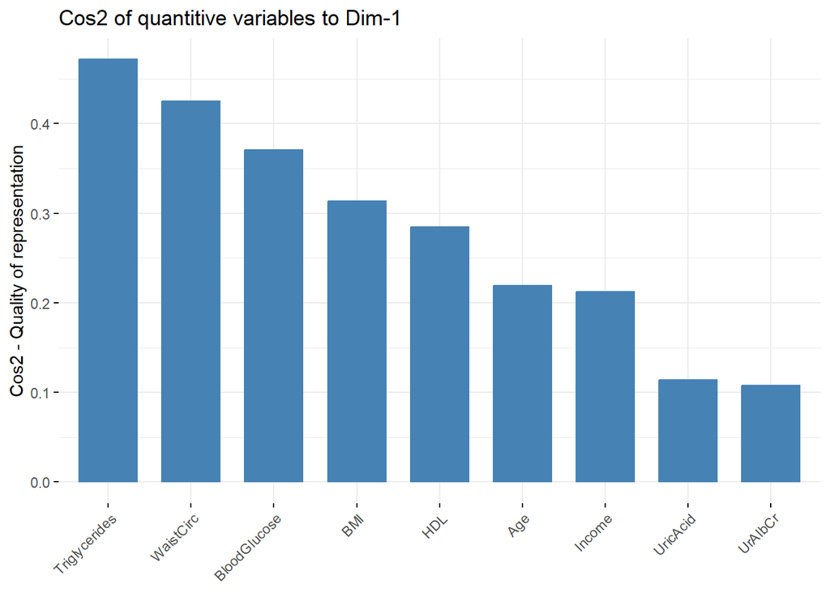

```r
fviz_cos2(dades.mfa, choice = "quanti.var", axes = 1)
```

### 2.1.5 Plotting individuals

To obtain the information of individuals

```r
ind <- get_mfa_ind(dades.mfa)
ind
```

```
## Multiple Factor Analysis results for individuals
##  ===================================================
##   Name                      Description
## 1 "$coord"                  "Coordinates"
## 2 "$cos2"                   "Cos2, quality of representation"
## 3 "$contrib"                "Contributions"
## 4 "$coord.partiel"          "Partial coordinates"
## 5 "$within.inertia"         "Within inertia"
## 6 "$within.partial.inertia" "Within partial inertia"
```

For instance

```r
head(ind$coord)
```

```
##           Dim.1      Dim.2       Dim.3      Dim.4      Dim.5
## 1564 -0.4789299  0.5843612 -1.23962748 -0.1957296 -0.1921185
## 2230 -1.1264470 -0.4633751 -0.99260849 -0.8455583  0.1516074
## 1235  0.3304260  1.9214711 -0.08787666  0.8880198  0.5279605
## 2314 -1.0997807  0.6138582 -1.43716994  0.5393967  0.3267869
## 1361  1.3936084 -1.0868654 -0.28575537 -0.8662260 -0.7132505
## 1218 -1.3101630 -0.7871862 -0.39798989 -0.9998127 -0.1172876
```

To plot individuals, use the function **fviz_mfa_ind()** [in factoextra]. By default, individuals are colored in blue. However, like variables, it’s also possible to color individuals by their cos2 values:

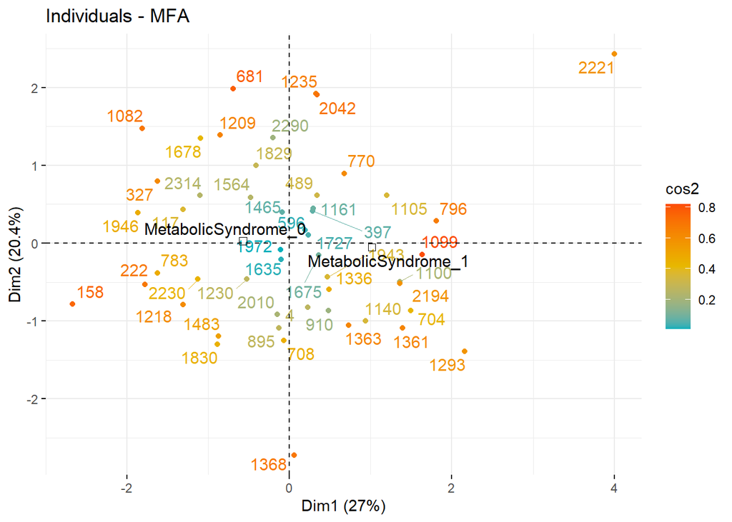

```r
fviz_mfa_ind(dades.mfa, col.ind = "cos2",
             gradient.cols = c("#00AFBB", "#E7B800", "#FC4E07"),
             repel = TRUE)
```

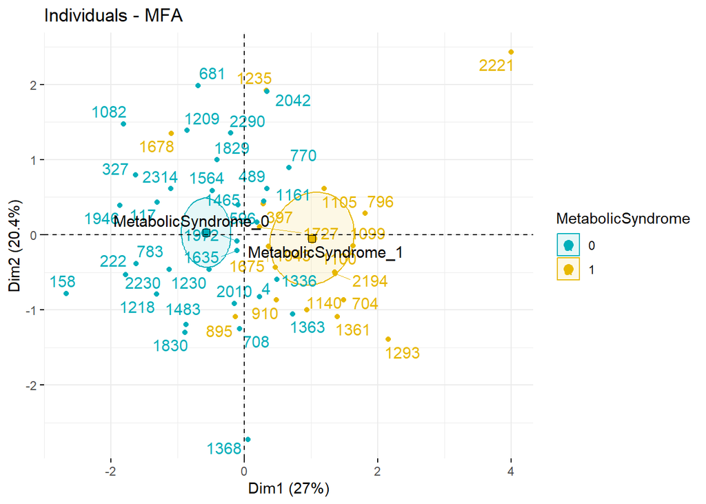

```r
fviz_mfa_ind(dades.mfa,
             habillage = "MetabolicSyndrome", # color by groups
             palette = c("#00AFBB", "#E7B800", "#FC4E07"),
             addEllipses = TRUE, ellipse.type = "confidence",
             repel = TRUE # Avoid text overlapping
             )
```

Other kinds of ellipses:

- “convex”: plot convex hull of a set o points.
- “confidence”: plot confidence ellipses arround group mean points as coord.ellipse()[in FactoMineR].
- “t”: assumes a multivariate t-distribution.
- “norm”: assumes a multivariate normal distribution. (**És l’opció per defecte**)
- “euclid”: draws a circle with the radius equal to level, representing the euclidean distance from the center. This ellipse probably won’t appear circular unless coord_fixed() is applied.

If we have more than one categorical variable we can do the simultaneous representation

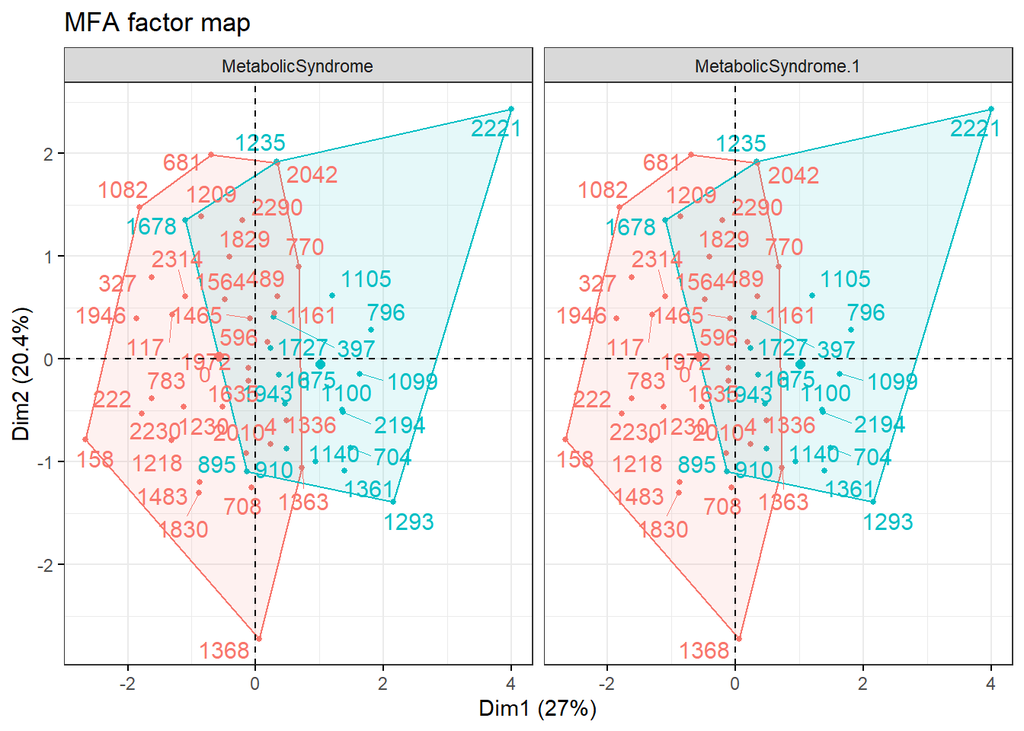

```r
fviz_ellipses(dades.mfa, c("MetabolicSyndrome","MetabolicSyndrome"), repel = TRUE,ellipse.type = "convex")
```

### 2.1.6 Partial Individuals Plot

The results for individuals obtained from the analysis performed with a single group are called partial individuals. In other words, an individual considered from the point of view of a single group is called a partial individual.

In the **fviz_mfa_ind()** plot, by default, for a given individual, the point corresponds to the average or the center of gravity of the individual’s partial points. That is, the individual seen by all groups of variables.

For a given individual, there are as many partial points as there are groups of variables.

The partial individuals plot represents each individual seen by each group and its center of gravity.

To represent the partial points of all individuals we use

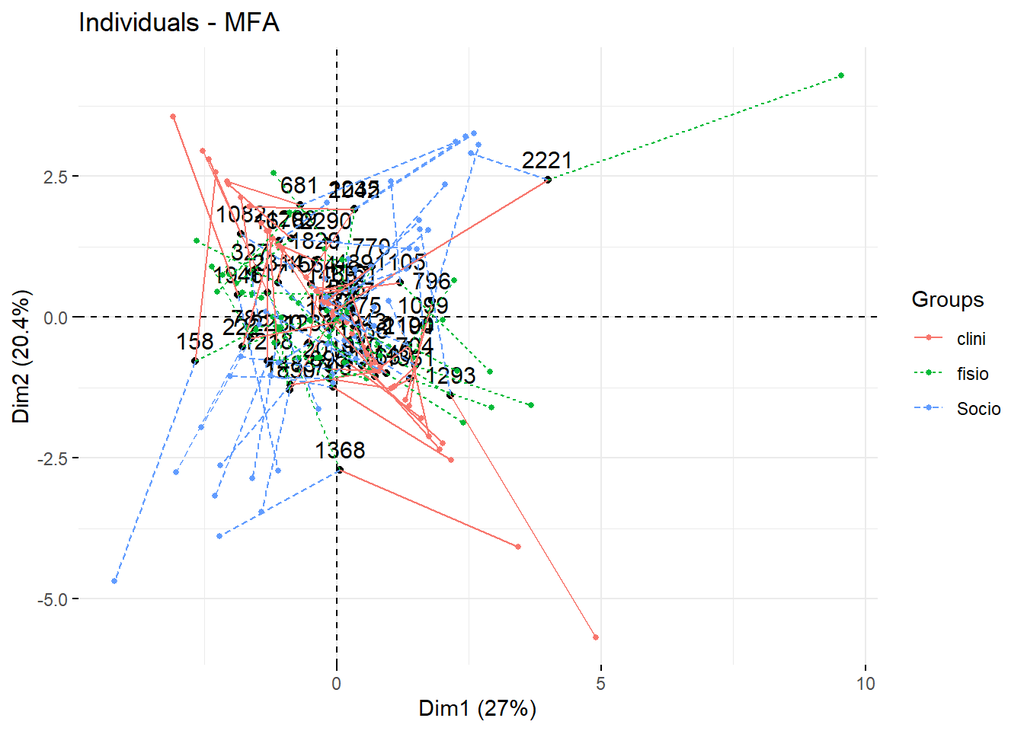

```r
fviz_mfa_ind(dades.mfa, partial = "all")
```

But if we want only some individuals

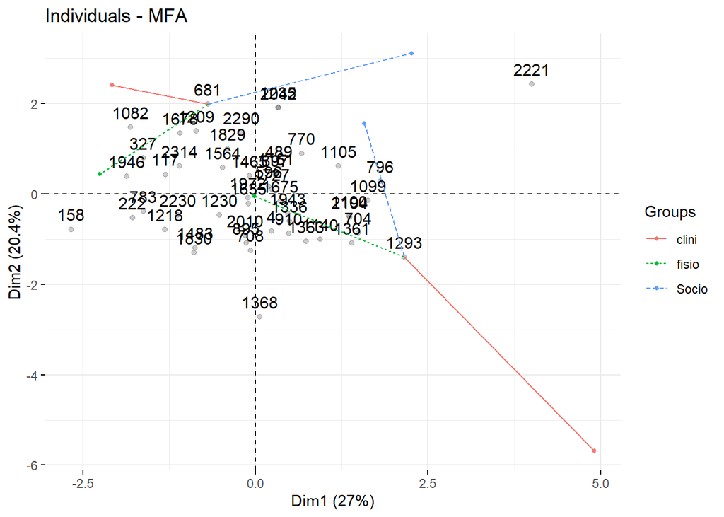

```r
fviz_mfa_ind(dades.mfa, partial = c("1293", "681"),alpha.ind=0.2)
```

o

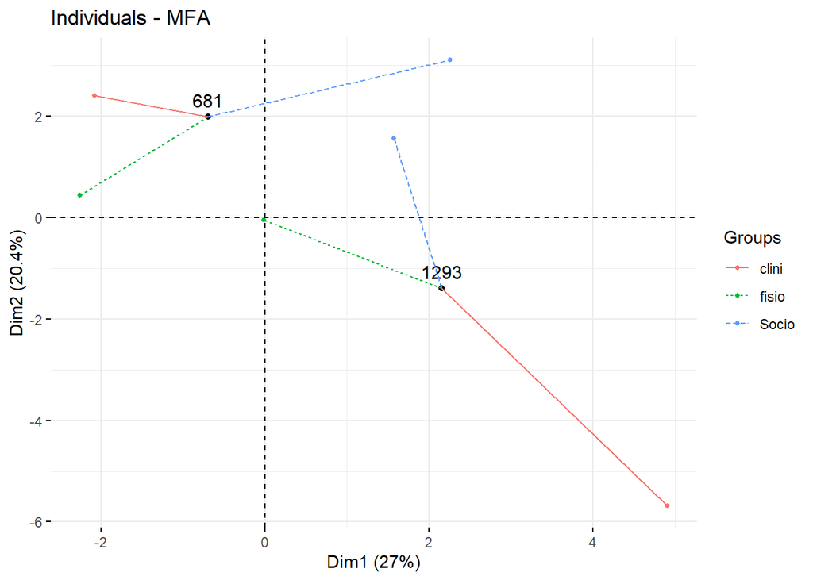

```r
fviz_mfa_ind(dades.mfa, partial = c("1293", "681"),select.ind = list(names=c("1293", "681")))
```

We can also achieve the representation with the **plot.MFA** function which allows us to further customize the output and specify for example whether the groups represent time instants (chrono=TRUE) with which we can visualize the temporal evolution of each individual.

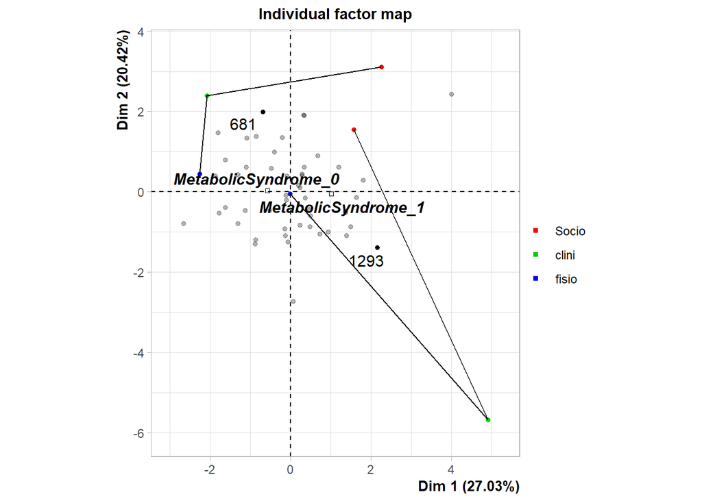

```r
plot(dades.mfa,partial=c("1293", "681"),chrono=T,select=c("1293", "681"))
```

### 2.1.7 Partial axes graph

The partial axes graph shows the relationship between the main axes of the MFA and those obtained from the analysis of each group using a PCA (for groups of continuous variables) or an MCA (for qualitative variables).

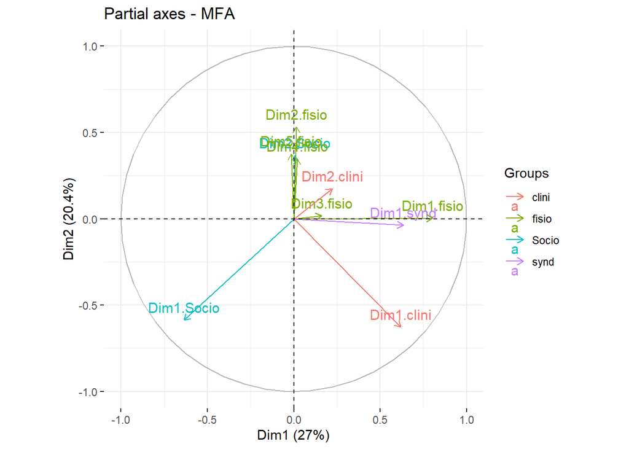

```r
fviz_mfa_axes(dades.mfa)
```

## 2.2 Additional interpretation of the axes

We can calculate the correlations of each variable with the axes and perform hypothesis testing

```r
dimdesc(dades.mfa)
```

```
## $Dim.1
##
## Link between the variable and the continuous variables (R-square)
## =================================================================================
##               correlation      p.value
## Triglycerides   0.6868974 3.626793e-08
## WaistCirc       0.6521762 2.881440e-07
## BloodGlucose    0.6089925 2.694570e-06
## BMI             0.5598186 2.369172e-05
## Age             0.4681621 6.068178e-04
## UricAcid        0.3371054 1.666845e-02
## UrAlbCr         0.3279082 2.008810e-02
## Income         -0.4605324 7.644409e-04
## HDL            -0.5337361 6.565370e-05
##
## Link between the variable and the categorical variable (1-way anova)
## =============================================
##                          R2      p.value
## MetabolicSyndrome 0.4019905 7.688372e-07
##
## Link between variable and the categories of the categorical variables
## ================================================================
##                     Estimate      p.value
## MetabolicSyndrome=1  0.79374 7.688372e-07
## MetabolicSyndrome=0 -0.79374 7.688372e-07
##
## $Dim.2
##
## Link between the variable and the continuous variables (R-square)
## =================================================================================
##              correlation      p.value
## Age            0.6796302 5.727207e-08
## HDL            0.4375798 1.484038e-03
## BloodGlucose   0.4053774 3.495065e-03
## UrAlbCr        0.2832143 4.626287e-02
## WaistCirc     -0.5767075 1.168147e-05
## BMI           -0.6488719 3.461903e-07
##
## $Dim.3
##
## Link between the variable and the continuous variables (R-square)
## =================================================================================
##        correlation      p.value
## Income   0.8449495 1.212820e-14
## Age      0.4089182 3.193707e-03
##
## Link between the variable and the categorical variable (1-way anova)
## =============================================
##                          R2    p.value
## MetabolicSyndrome 0.1147947 0.01609116
##
## Link between variable and the categories of the categorical variables
## ================================================================
##                       Estimate    p.value
## MetabolicSyndrome=1  0.3291791 0.01609116
## MetabolicSyndrome=0 -0.3291791 0.01609116
```

# 3 Separate results for each group (PCA or MCA)

All results are accessible for each group separately just as if we had done a PCA or MCA on each group of variables.

For example if we focus on the group of physiological variables

```r
fisio_var<-get_pca_var(dades.mfa$separate.analyses$fisio)
fisio_var$coord
```

```
##                    Dim.1       Dim.2       Dim.3      Dim.4       Dim.5
## UrAlbCr        0.2544221  0.63550613  0.71537326 -0.1216139 -0.06965988
## UricAcid       0.3337929 -0.73237116  0.47125891  0.3459315  0.10228022
## BloodGlucose   0.7948718  0.43626109 -0.20279592  0.1175588  0.35058357
## HDL           -0.6859613  0.48237423 -0.01067182  0.5444359 -0.01574375
## Triglycerides  0.8841407  0.07565754 -0.20973290  0.2211068 -0.34596983
```

```r
fisio_ind<-get_pca_ind(dades.mfa$separate.analyses$fisio)
head(fisio_ind$coord)
```

```
##           Dim.1      Dim.2      Dim.3      Dim.4       Dim.5
## 1564 -0.4646609  0.1146720 -0.3826233 0.04797478  0.54877631
## 2230 -0.3087776 -0.1384398 -0.4854003 0.25373790 -0.03804697
## 1235 -0.6505202  1.9759527 -0.2499470 0.96068668 -0.65786610
## 2314 -1.8512524  1.0417141 -0.7015286 1.97803160 -0.71614915
## 1361  2.1248696 -1.6772786 -0.0710019 0.24104645 -0.95336375
## 1218 -0.2031369 -0.7515772 -0.1212052 0.23554510 -0.49315552
```

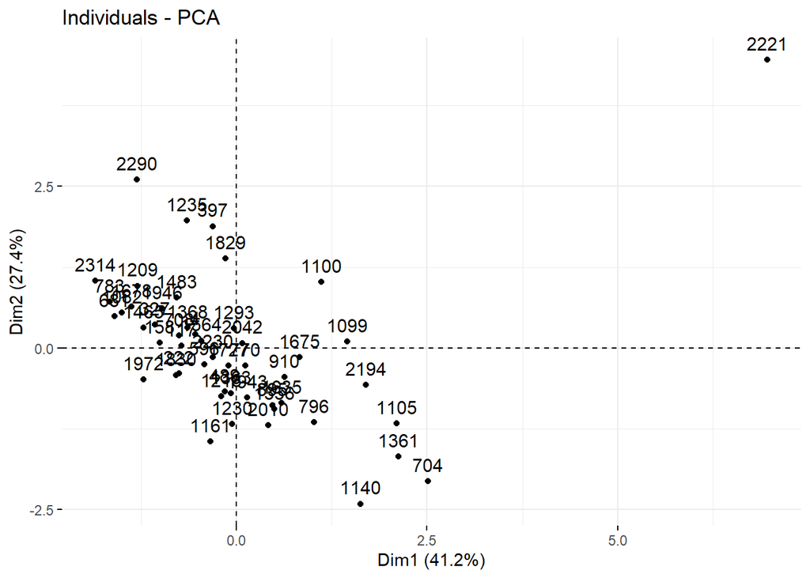

```r
fviz_pca_ind(dades.mfa$separate.analyses$fisio)
```

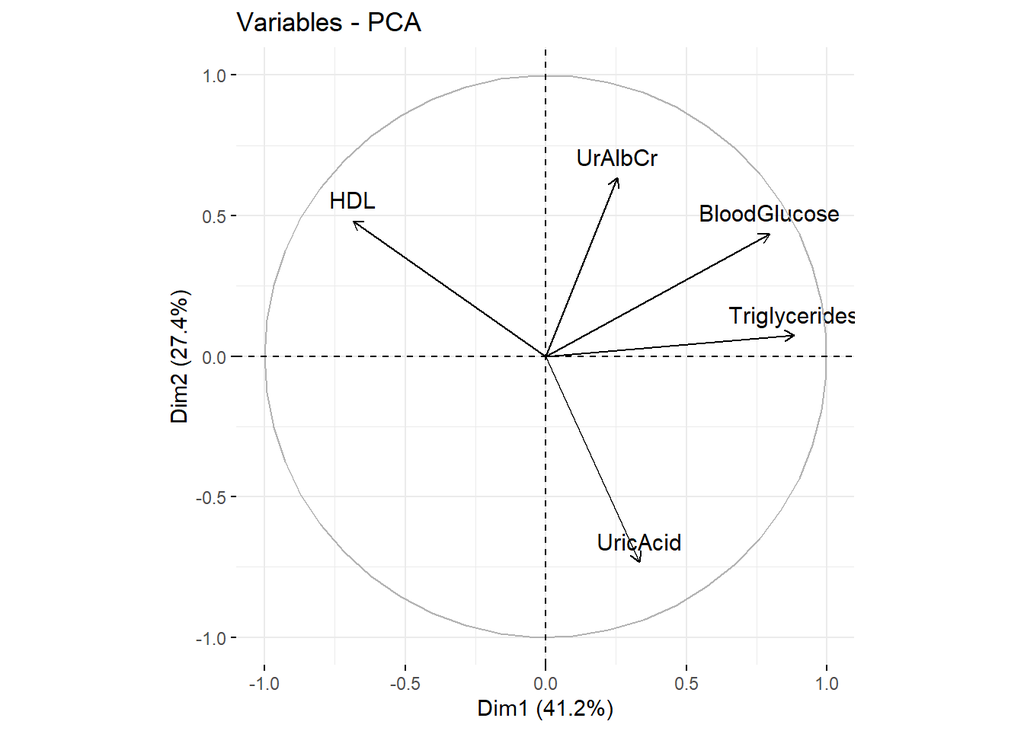

```r
fviz_pca_var(dades.mfa$separate.analyses$fisio)
```

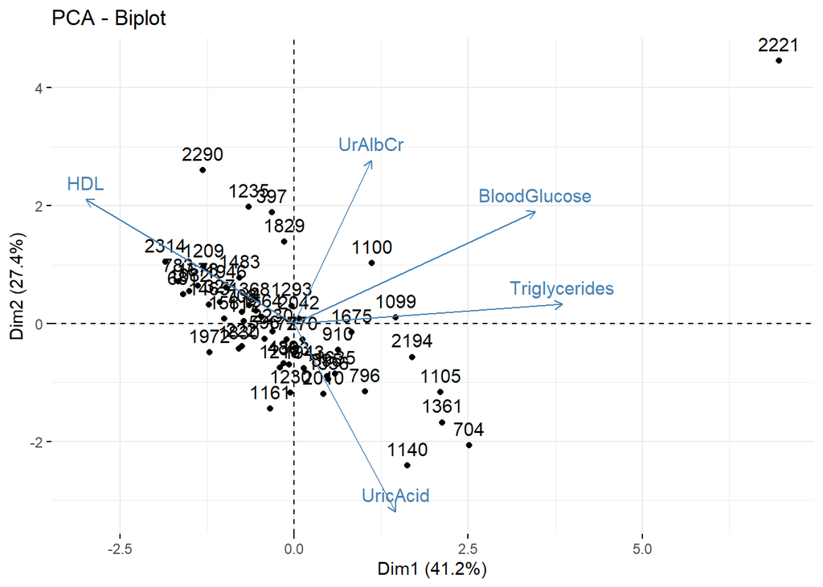

```r
fviz_pca_biplot(dades.mfa$separate.analyses$fisio)
```

If we had done the PCA separately

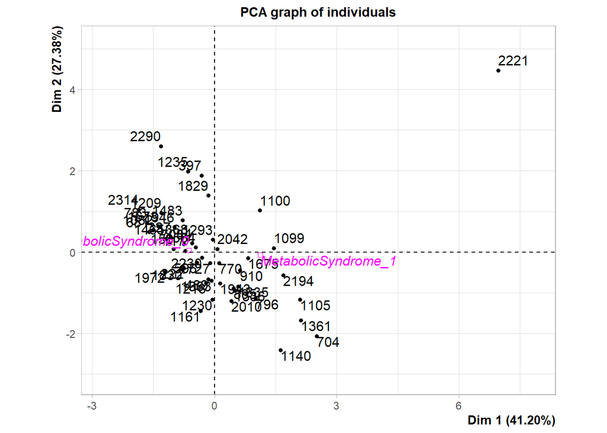

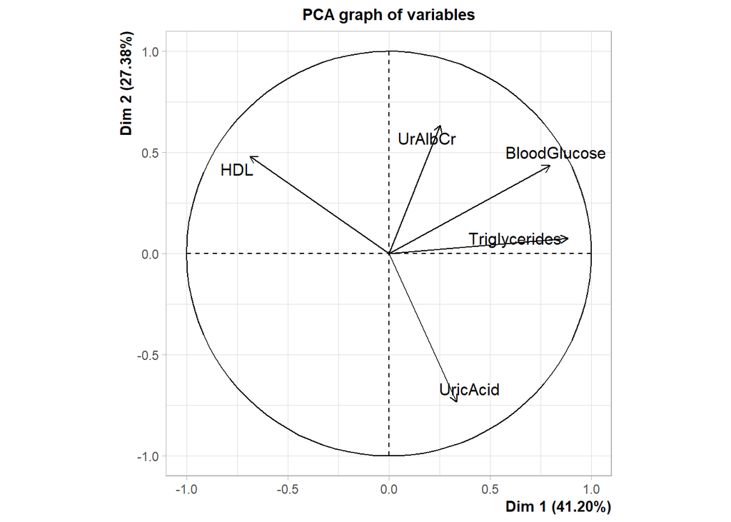

```r
dades.pca<-PCA(dades[,10:15],quali.sup=6)
```

```r
summary(dades.pca)
```

```
##
## Call:
## PCA(X = dades[, 10:15], quali.sup = 6)
##
##
## Eigenvalues
##                        Dim.1   Dim.2   Dim.3   Dim.4   Dim.5
## Variance               2.060   1.369   0.819   0.494   0.258
## % of var.             41.204  27.379  16.381   9.872   5.163
## Cumulative % of var.  41.204  68.584  84.965  94.837 100.000
##
## Individuals (the 10 first)
##                         Dist    Dim.1    ctr   cos2    Dim.2    ctr   cos2
## 1564                |  0.824 | -0.465  0.210  0.318 |  0.115  0.019  0.019 |
## 2230                |  0.645 | -0.309  0.093  0.229 | -0.138  0.028  0.046 |
## 1235                |  2.397 | -0.651  0.411  0.074 |  1.976  5.704  0.680 |
## 2314                |  3.071 | -1.851  3.327  0.363 |  1.042  1.585  0.115 |
## 1361                |  2.881 |  2.125  4.383  0.544 | -1.677  4.110  0.339 |
## 1218                |  0.959 | -0.203  0.040  0.045 | -0.752  0.825  0.614 |
## 770                 |  0.811 |  0.118  0.013  0.021 | -0.274  0.110  0.115 |
## 1105                |  2.409 |  2.099  4.278  0.759 | -1.166  1.987  0.234 |
## 796                 |  1.685 |  1.017  1.004  0.364 | -1.149  1.929  0.465 |
## 1140                |  3.228 |  1.627  2.569  0.254 | -2.410  8.487  0.557 |
##                      Dim.3    ctr   cos2
## 1564                -0.383  0.357  0.216 |
## 2230                -0.485  0.575  0.566 |
## 1235                -0.250  0.153  0.011 |
## 2314                -0.702  1.202  0.052 |
## 1361                -0.071  0.012  0.001 |
## 1218                -0.121  0.036  0.016 |
## 770                  0.208  0.106  0.066 |
## 1105                -0.040  0.004  0.000 |
## 796                  0.307  0.230  0.033 |
## 1140                 0.954  2.222  0.087 |
##
## Variables
##                        Dim.1    ctr   cos2    Dim.2    ctr   cos2    Dim.3
## UrAlbCr             |  0.254  3.142  0.065 |  0.636 29.502  0.404 |  0.715
## UricAcid            |  0.334  5.408  0.111 | -0.732 39.180  0.536 |  0.471
## BloodGlucose        |  0.795 30.668  0.632 |  0.436 13.903  0.190 | -0.203
## HDL                 | -0.686 22.839  0.471 |  0.482 16.997  0.233 | -0.011
## Triglycerides       |  0.884 37.943  0.782 |  0.076  0.418  0.006 | -0.210
##                        ctr   cos2
## UrAlbCr             62.480  0.512 |
## UricAcid            27.114  0.222 |
## BloodGlucose         5.021  0.041 |
## HDL                  0.014  0.000 |
## Triglycerides        5.370  0.044 |
##
## Supplementary categories
##                         Dist    Dim.1   cos2 v.test    Dim.2   cos2 v.test
## MetabolicSyndrome_0 |  0.641 | -0.631  0.969 -4.102 |  0.036  0.003  0.288 |
## MetabolicSyndrome_1 |  1.139 |  1.121  0.969  4.102 | -0.064  0.003 -0.288 |
##                      Dim.3   cos2 v.test
## MetabolicSyndrome_0 -0.081  0.016 -0.831 |
## MetabolicSyndrome_1  0.143  0.016  0.831 |
```

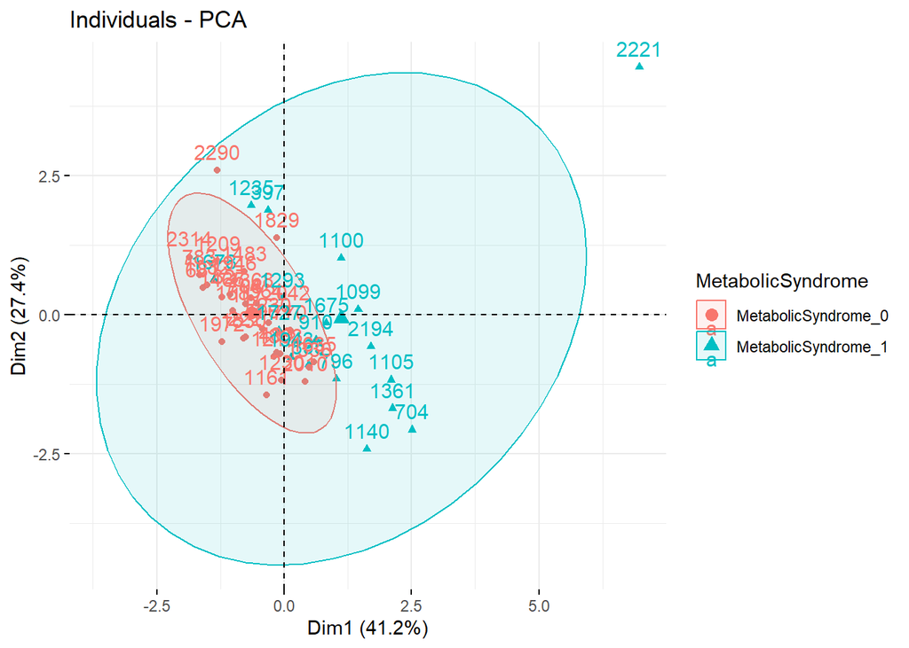

```r
fviz_pca_ind(dades.pca,habillage='MetabolicSyndrome',addEllipses = T)
```

# 4 Analysis with groups of qualitative variables

The methodology is the same but replaces PCA with Multiple Correspondence Analysis (MCA)

We can see an example of MCA in the following document MCA.html

```r
dades2mfa.2<-dades[,c(3,4,6,2,5,7,8,10:15)]
group<-c(3,2,2,5,1)
type<-c('n','s','s','s','n')
name.group<-c('carac','Socio','clini','fisio','synd')
dades.mfa.2<-MFA(dades2mfa.2,group=group,type=type,name.group = name.group,graph = F,num.group.sup = 5)
```

## 4.1 Summary of results

```r
summary(dades.mfa.2)
```

```
##
## Call:
## MFA(base = dades2mfa.2, group = group, type = type, name.group = name.group,
##      num.group.sup = 5, graph = F)
##
##
## Eigenvalues
##                        Dim.1   Dim.2   Dim.3   Dim.4   Dim.5   Dim.6   Dim.7
## Variance               1.686   1.406   1.142   1.103   0.976   0.858   0.804
## % of var.             14.355  11.965   9.718   9.393   8.311   7.307   6.844
## Cumulative % of var.  14.355  26.321  36.039  45.432  53.743  61.050  67.893
##                        Dim.8   Dim.9  Dim.10  Dim.11  Dim.12  Dim.13  Dim.14
## Variance               0.652   0.642   0.528   0.468   0.393   0.326   0.273
## % of var.              5.552   5.468   4.496   3.985   3.343   2.773   2.322
## Cumulative % of var.  73.445  78.913  83.408  87.393  90.736  93.509  95.831
##                       Dim.15  Dim.16  Dim.17  Dim.18  Dim.19
## Variance               0.181   0.147   0.093   0.053   0.015
## % of var.              1.544   1.252   0.791   0.453   0.127
## Cumulative % of var.  97.376  98.628  99.419  99.873 100.000
##
## Groups
##                        Dim.1    ctr   cos2    Dim.2    ctr   cos2    Dim.3
## carac               |  0.388 23.010  0.033 |  0.539 38.370  0.064 |  0.541
## Socio               |  0.362 21.453  0.074 |  0.538 38.284  0.164 |  0.314
## clini               |  0.419 24.818  0.175 |  0.073  5.211  0.005 |  0.009
## fisio               |  0.518 30.719  0.160 |  0.255 18.135  0.039 |  0.278
##                        ctr   cos2
## carac               47.379  0.065 |
## Socio               27.512  0.056 |
## clini                0.756  0.000 |
## fisio               24.353  0.046 |
##
## Supplementary group
##                       Dim.1  cos2   Dim.2  cos2   Dim.3  cos2
## synd                | 0.345 0.119 | 0.003 0.000 | 0.147 0.022 |
##
## Individuals (the 10 first)
##                        Dim.1    ctr   cos2    Dim.2    ctr   cos2    Dim.3
## 1564                | -0.157  0.029  0.004 |  0.260  0.096  0.011 | -0.734
## 2230                | -0.286  0.097  0.008 | -1.122  1.791  0.130 | -0.798
```

[output cut: 58 more lines]

```
## Married             |  0.877 15.130  0.617  4.694 |
## Separated           | -1.433  2.018  0.044 -1.341 |
## Single              | -0.646  5.336  0.157 -2.510 |
## Widowed             | -0.831  2.716  0.070 -1.606 |
## Asian               |  0.114  0.116  0.003  0.351 |
## Black               | -0.278  0.984  0.036 -1.078 |
## Hispanic            |  0.273  0.293  0.009  0.528 |
##
## Supplementary categories
##                        Dim.1   cos2 v.test    Dim.2   cos2 v.test    Dim.3
## MetabolicSyndrome_0 | -0.572  0.724 -4.109 | -0.050  0.006 -0.393 | -0.308
## MetabolicSyndrome_1 |  1.016  0.724  4.109 |  0.089  0.006  0.393 |  0.547
##                       cos2 v.test
## MetabolicSyndrome_0  0.210 -2.688 |
## MetabolicSyndrome_1  0.210  2.688 |
```

### 4.1.1 Explained variance

```r
eig.val <- get_eigenvalue(dades.mfa.2)
head(eig.val)
```

```
##       eigenvalue variance.percent cumulative.variance.percent
## Dim.1  1.6863312        14.355477                    14.35548
## Dim.2  1.4055403        11.965148                    26.32062
## Dim.3  1.1415858         9.718144                    36.03877
## Dim.4  1.1034239         9.393278                    45.43205
## Dim.5  0.9762349         8.310537                    53.74258
## Dim.6  0.8583481         7.306985                    61.04957
```

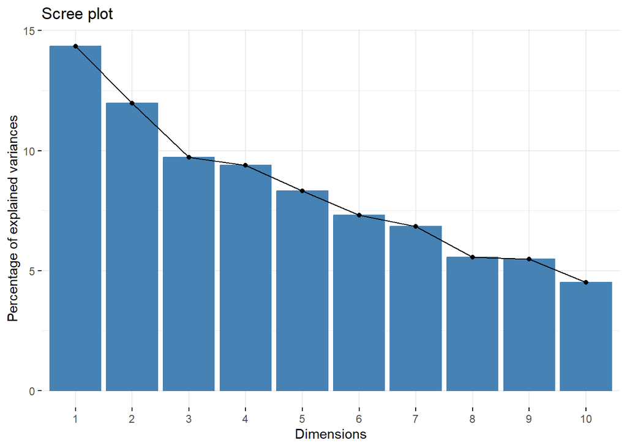

```r
fviz_eig(dades.mfa.2)
```

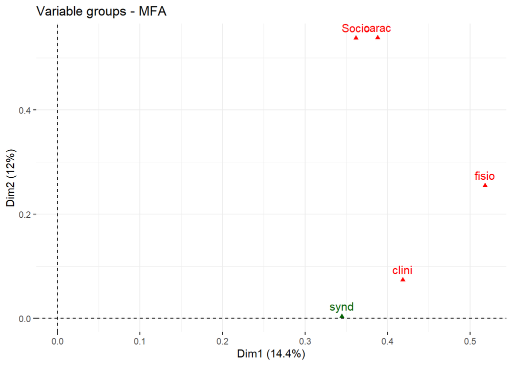

```r
fviz_mfa_var(dades.mfa.2, "group")
```

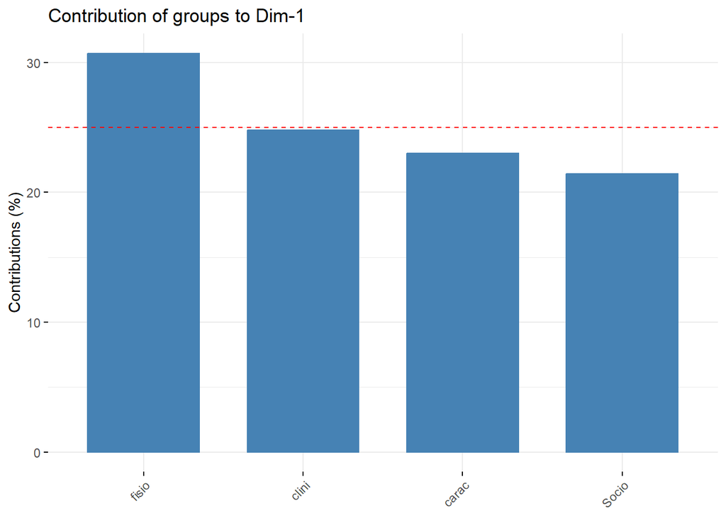

```r
# Contribution to the first dimension
fviz_contrib(dades.mfa.2, "group", axes = 1)
```

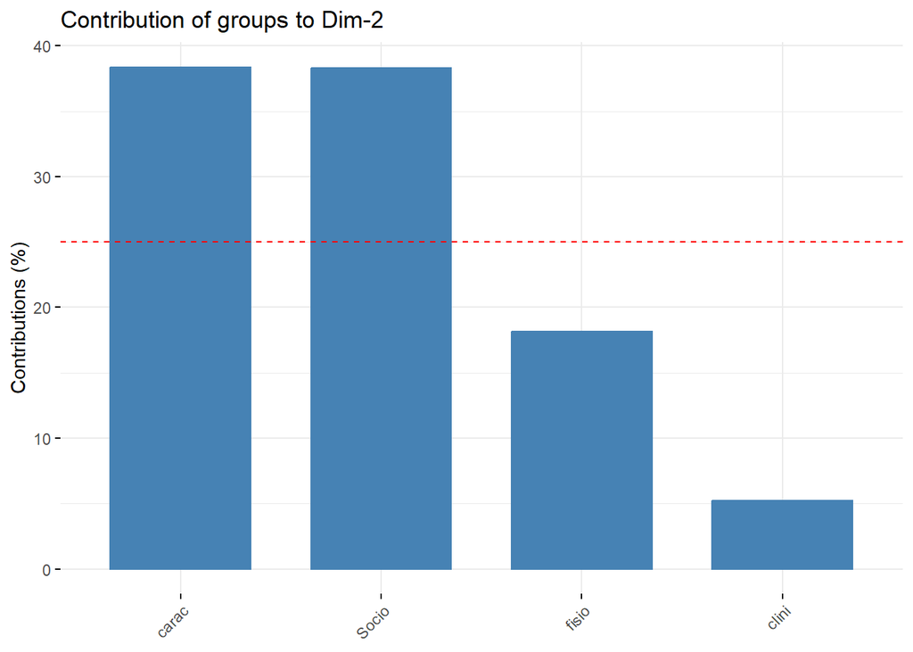

```r
# Contribution to the second dimension
fviz_contrib(dades.mfa.2, "group", axes = 2)
```